# Introduction

### Application of SCR: Time-homogeneity Test and Separability Test

We can also present two important examples of structure test

(1). Testing time-homogeneity $$\boldsymbol H_0: m_j(t, x) = m_{j}(x), \forall t \in [0,1]$$ For this test, we estimate function only using $\varphi(x)$(the basis function of $x$), then compare $\hat{m}_{j}(x)$ and the SCR of $\hat{m}_{j}(t, x)$.

If the plot of $\hat{m}_{j}(x)$ is not in the SCR of $\hat{m}_{j}(t, x)$, we reject the null hypothesis, which means we time is inhomogeneous.

(2). Testing separability $$\boldsymbol H_0: m_j(t, x) = f_{j}(t)g_j(x) , \forall t \in [0,1], x \in \mathbb{R}$$ For this test, we estimate $f_j(t)$ by $$\hat{f}_j(t) = \int_{0}^{1} \hat{m}_{j}(t, x)dx$$ and $g_j(x)$ by $$\hat{g}_j(x) = \int_{\mathbb{R}} \hat{m}_{j}(t, x)dt$$ Then we compare $\frac{\hat{f}_j(t)\hat{g}_j(x)}{\iint \hat{m}_{j}(t, x)dtdx}$ and the SCR of $\hat{m}_{j}(t, x)$

If the plot of $\frac{\hat{f}_j(t)\hat{g}_j(x)}{\iint \hat{m}_{j}(t, x)dtdx}$ is not in the SCR of $\hat{m}_{j}(t, x)$, we reject the null hypothesis, which means we think it is not separable.

## Simulation for Estimation

we use a nonlinear AR(1) model to simulate where $Y_i = X_i$, $X_{j, i} = X_{i-j}$: $$X_i = \sin(2\pi\frac{i}{n}) e^{-X_{i-1}^2} + \epsilon_{i}$$

```python
def series_generator_example(n):
    np.random.seed(2022)
    x = list(np.random.randn(1))
    for i in range(1, n):
        x.append((math.sin(2 * np.pi * (i + 1) / n)) * math.exp(- x[-1] ** 2) + np.random.normal())
    return x
```

```python
def true_function_series(t, x):
    return (math.sin(2 * np.pi * t)) * math.exp(- x ** 2)
```

```python
n = 4000
series = np.array(series_generator_example(n))
```

```python
b = 1
c1 = 5
c2 = 4
```

```python
sieve_obj = SieveOLS2D(series, series, 'legendre', 'legendre', 'algebraic', b, c1, c2)
```

In order to demonstrate the asymptotic property of $\hat{m}_{j, c, d}(t, x)$ to $m_{j}(t, x)$, we both draw several 2-d plots where we fixed one variable of $t, x$ and change another and also a 3-d plot. We could find the estimated function and true function plot close to each other

```python
flexible_sequence_time = np.arange(1, n) / n
flexible_sequence_series = np.arange(1, 5 * n) / n
b_index = 1
```

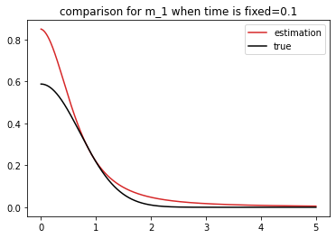

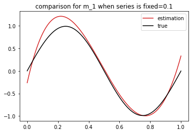

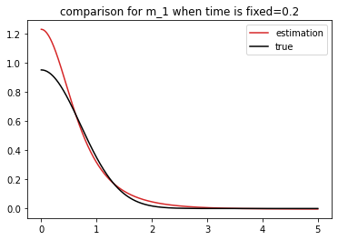

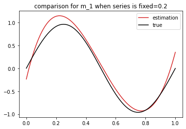

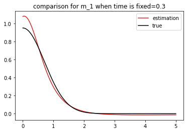

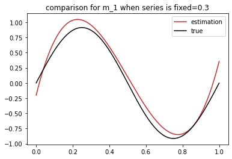

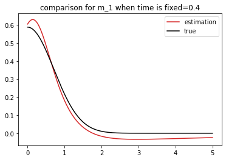

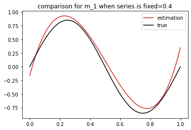

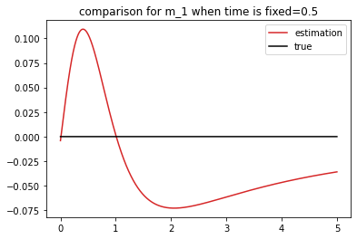

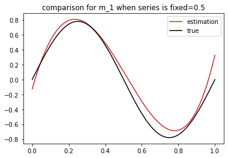

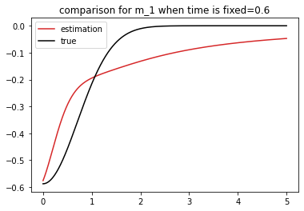

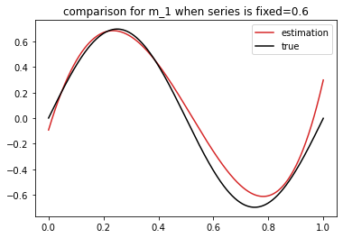

[6 more figures not shown]

```python
for fixed_value in np.arange(1, 10) / 10:
    sieve_obj.mimic_function_compara(true_function_series, 'time', fixed_value, flexible_sequence_series, b_index)
    sieve_obj.mimic_function_compara(true_function_series, 'series', fixed_value, flexible_sequence_time, b_index)
```

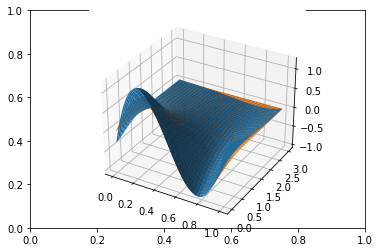

```python
sieve_obj.mimic_function_compara_3d(true_function_series, 1, np.arange(0, 1.001, 0.01), np.arange(0, 3.001, 0.01))
```

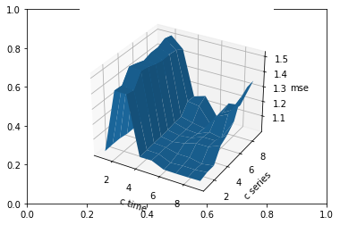

```python
sieve_obj.cross_validation()
```

From the results of cross validation, we prefer to choose $c = 5$ and $d = 2$, because it has relatively small $MSE$ and parameters.

## Simulation for Inference

We still use the previous nonlinear AR(1) model to simulate where $Y_i = X_i$, $X_{j, i} = X_{i-j}$: $$X_i = \sin(2\pi\frac{i}{n}) e^{-X_{i-1}^2} + \epsilon_{i}$$

### Simulation for Simultaneous Confidence Region(SCR)

```python
def null_function_1(t, x):
    return (math.sin(2 * np.pi * t)) * math.exp(- x ** 2)
```

```python
def null_function_2(t, x):
    return (math.sin(2 * np.pi * t) + 1) * math.exp(- x ** 2)
```

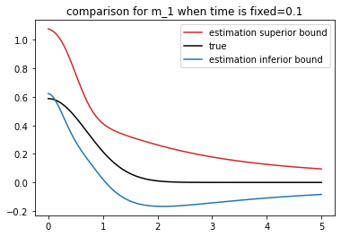

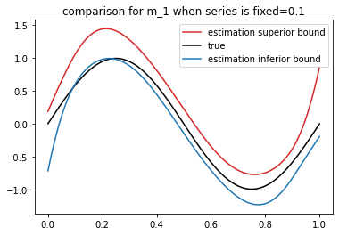

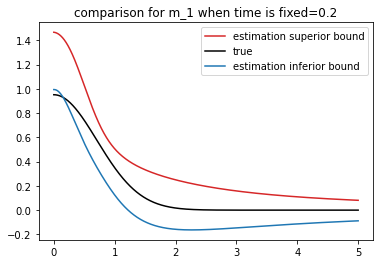

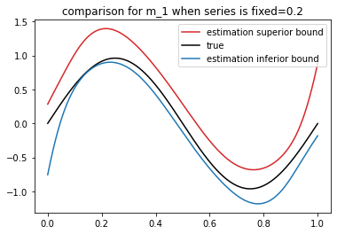

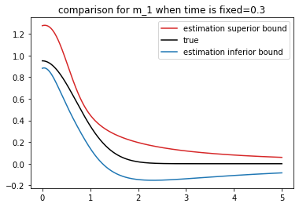

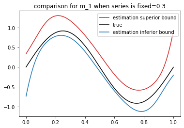

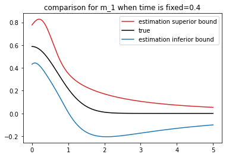

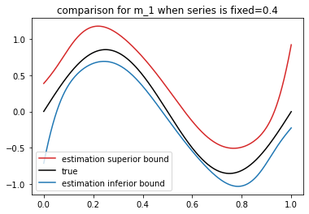

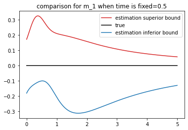

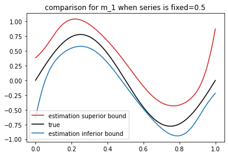

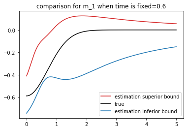

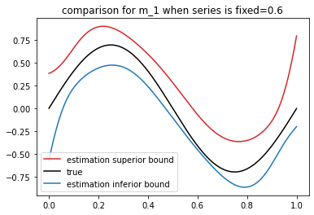

[6 more figures not shown]

```python
for fixed_value in np.arange(1, 10) / 10:
    sieve_obj.simultaneous_confidence_region_compara(null_function_1, 'time', fixed_value, flexible_sequence_series, b_index)
    sieve_obj.simultaneous_confidence_region_compara(null_function_1, 'series', fixed_value, flexible_sequence_time, b_index)
```

### Simulation for Time-homogeneity Test

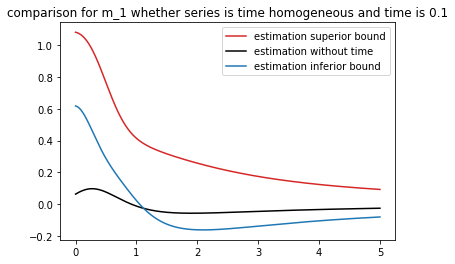

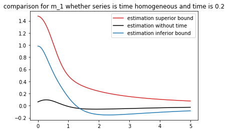

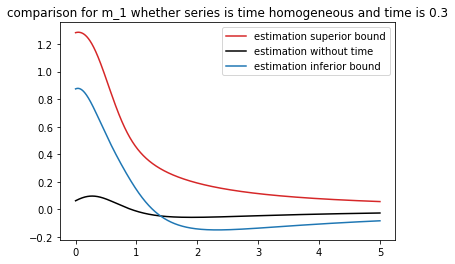

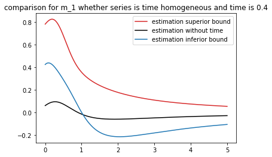

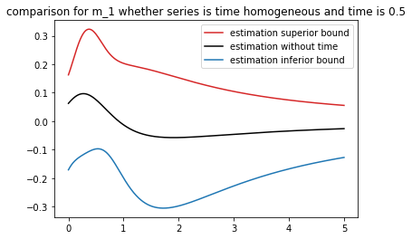

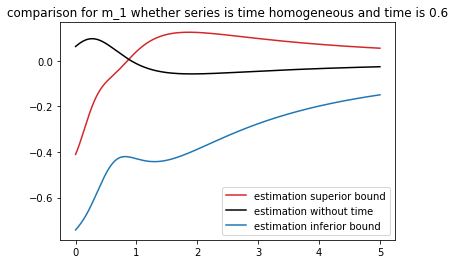

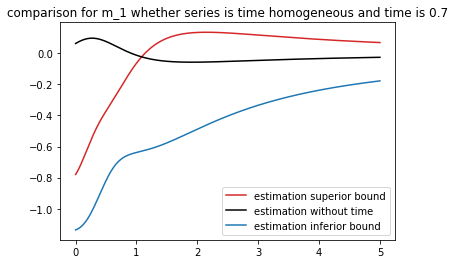

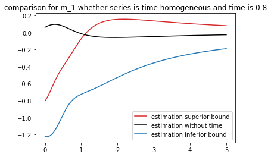

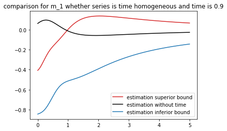

```python
for fixed_value in np.arange(1, 10) / 10:
    sieve_obj.time_homogeneity_compara(flexible_sequence_series, any_time = fixed_value)
```

The plots indicate we should reject the null hypothesis.

We also try a new AR(1) model to simulate where $Y_i = X_i$, $X_{j, i} = X_{i-j}$: $$X_i = e^{-X_{i-1}^2} + \epsilon_{i}$$

```python
def series_generator_example2(n):
    np.random.seed(2022)
    x = list(np.random.randn(1))
    for i in range(1, n):
        x.append(math.exp(- x[-1] ** 2) + np.random.normal())
    return x
```

```python
n = 4000
series2 = np.array(series_generator_example2(n))
```

```python
sieve_obj2 = SieveOLS2D(series2, series2, 'legendre', 'legendre', 'algebraic', b, c1, c2)
```

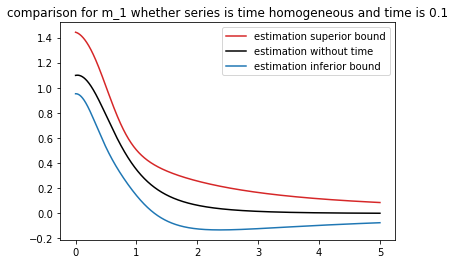

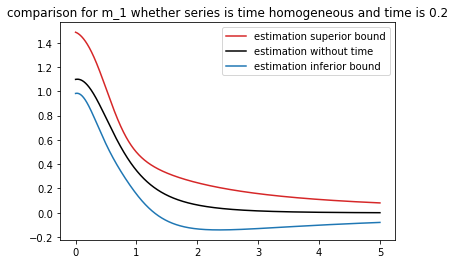

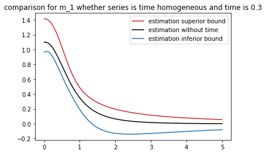

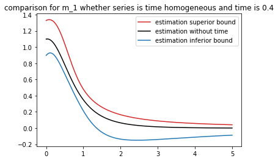

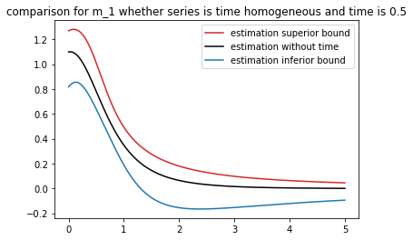

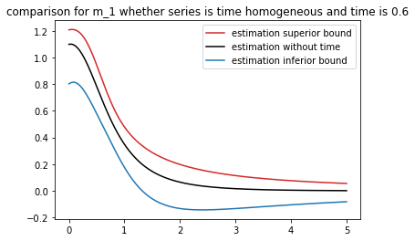

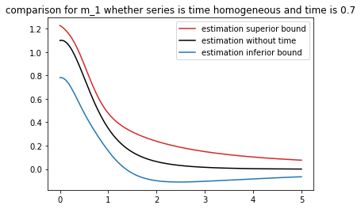

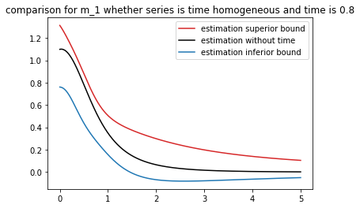

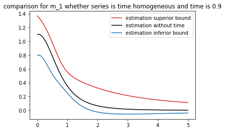

```python
for fixed_value in np.arange(1, 10) / 10:
    sieve_obj2.time_homogeneity_compara(flexible_sequence_series, any_time = fixed_value)
```

The plots indicate we can not reject the null hypothesis for the new AR(1) series.

### Simulation for Separability Test

```python
def series_generator_example3(n):
    np.random.seed(1)
    x = list(np.random.randn(1))
    for i in range(1, n):
        x.append((math.sin(2 * np.pi * (i + 1) / n) + 2) * math.exp(- x[-1] ** 2) + np.random.normal())
    return x
```

```python
series3 = np.array(series_generator_example3(n))
```

```python
fixed_value_sequence = np.arange(1, 10) / 10
sequence_time = np.arange(1, 100) / 100
sequence_series = np.arange(1, 500) / 100
```

```python
sieve_obj3 = SieveOLS2D(series3, series3, 'legendre', 'legendre', 'algebraic', b, c1, c2)
```

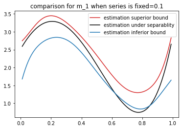

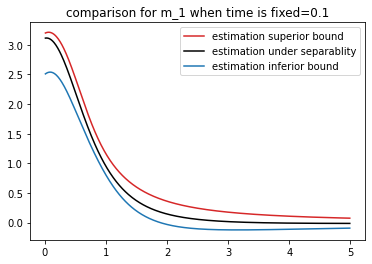

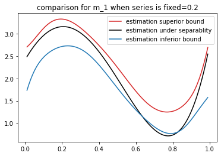

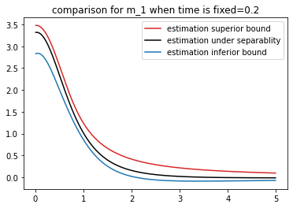

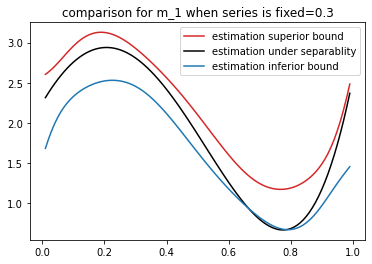

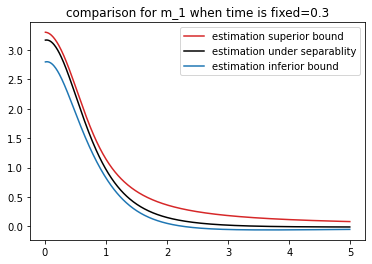

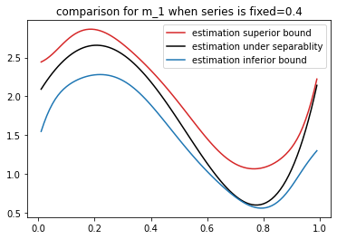

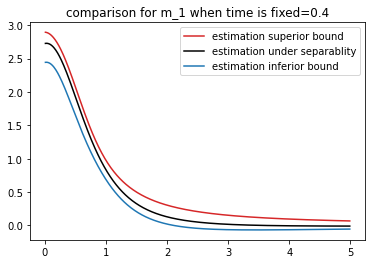

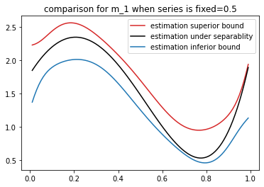

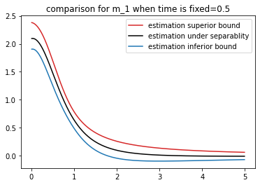

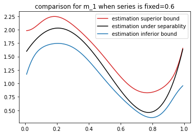

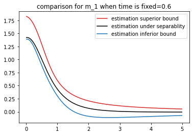

[6 more figures not shown]

```python
sieve_obj3.separablity(fixed_value_sequence, sequence_time, sequence_series)
```